# tidyr介绍

```r
library(tidyr)
library(dplyr)
library(readr)
```

# longer：纵向拉长数据

## 典型场景1

```r
relig_income
```

| religion | <$10k | $10-20k | $20-30k | $30-40k | $40-50k | $50-75k | $75-100k | $100-150k | >150k | Don't know/refused |
| --- | --- | --- | --- | --- | --- | --- | --- | --- | --- | --- |
| Agnostic | 27 | 34 | 60 | 81 | 76 | 137 | 122 | 109 | 84 | 96 |
| Atheist | 12 | 27 | 37 | 52 | 35 | 70 | 73 | 59 | 74 | 76 |
| Buddhist | 27 | 21 | 30 | 34 | 33 | 58 | 62 | 39 | 53 | 54 |
| Catholic | 418 | 617 | 732 | 670 | 638 | 1116 | 949 | 792 | 633 | 1489 |
| Don’t know/refused | 15 | 14 | 15 | 11 | 10 | 35 | 21 | 17 | 18 | 116 |
| Evangelical Prot | 575 | 869 | 1064 | 982 | 881 | 1486 | 949 | 723 | 414 | 1529 |
| Hindu | 1 | 9 | 7 | 9 | 11 | 34 | 47 | 48 | 54 | 37 |
| Historically Black Prot | 228 | 244 | 236 | 238 | 197 | 223 | 131 | 81 | 78 | 339 |
| Jehovah's Witness | 20 | 27 | 24 | 24 | 21 | 30 | 15 | 11 | 6 | 37 |
| Jewish | 19 | 19 | 25 | 25 | 30 | 95 | 69 | 87 | 151 | 162 |

[output cut: 8 more lines]

这个数据从本质上来说包括三个变量： 1. religion, 分布在行上 2. income，分布在列名上 3. count，分布在单元格中

```r
relig_income %>%
  pivot_longer(-religion, names_to = "income", values_to = "count")
```

| religion | income | count |
| --- | --- | --- |
| Agnostic | <$10k | 27 |
| Agnostic | $10-20k | 34 |
| Agnostic | $20-30k | 60 |
| Agnostic | $30-40k | 81 |
| Agnostic | $40-50k | 76 |
| Agnostic | $50-75k | 137 |
| Agnostic | $75-100k | 122 |
| Agnostic | $100-150k | 109 |
| Agnostic | >150k | 84 |
| Agnostic | Don't know/refused | 96 |

[output cut: 170 more lines]

主力函数`pivot_longer`参数： 1. 数据本身 2. 指定哪些列需要变形(reshape), 本例中是所有列，除了第一列。 3. `names_to` 指定变形之后的列名 4. `values_to` 指定单元格数据的列名

注意 `names_to`和`values_to`都是原数据`relig_income`中没有的列名。

## 典型场景2

`billboard`数据搜集了2000年歌曲排行版的数据。与上一个数据的情况类似， 但是存在列名上的不再是字符串，而应该是数值（星期几）

```r
billboard
```

| artist | track | date.entered | wk1 | wk2 | wk3 | wk4 | wk5 | wk6 | wk7 | wk8 | wk9 | wk10 | wk11 | wk12 | wk13 | wk14 | wk15 | wk16 | wk17 | wk18 | wk19 | wk20 | wk21 | wk22 | wk23 | wk24 | wk25 | wk26 | wk27 | … |
| --- | --- | --- | --- | --- | --- | --- | --- | --- | --- | --- | --- | --- | --- | --- | --- | --- | --- | --- | --- | --- | --- | --- | --- | --- | --- | --- | --- | --- | --- | --- |
| 2 Pac | Baby Don't Cry (Keep... | 2000-02-26 | 87 | 82 | 72 | 77 | 87 | 94 | 99 | NA | NA | NA | NA | NA | NA | NA | NA | NA | NA | NA | NA | NA | NA | NA | NA | NA | NA | NA | NA | … |
| 2Ge+her | The Hardest Part Of ... | 2000-09-02 | 91 | 87 | 92 | NA | NA | NA | NA | NA | NA | NA | NA | NA | NA | NA | NA | NA | NA | NA | NA | NA | NA | NA | NA | NA | NA | NA | NA | … |
| 3 Doors Down | Kryptonite | 2000-04-08 | 81 | 70 | 68 | 67 | 66 | 57 | 54 | 53 | 51 | 51 | 51 | 51 | 47 | 44 | 38 | 28 | 22 | 18 | 18 | 14 | 12 | 7 | 6 | 6 | 6 | 5 | 5 | … |
| 3 Doors Down | Loser | 2000-10-21 | 76 | 76 | 72 | 69 | 67 | 65 | 55 | 59 | 62 | 61 | 61 | 59 | 61 | 66 | 72 | 76 | 75 | 67 | 73 | 70 | NA | NA | NA | NA | NA | NA | NA | … |
| 504 Boyz | Wobble Wobble | 2000-04-15 | 57 | 34 | 25 | 17 | 17 | 31 | 36 | 49 | 53 | 57 | 64 | 70 | 75 | 76 | 78 | 85 | 92 | 96 | NA | NA | NA | NA | NA | NA | NA | NA | NA | … |
| 98^0 | Give Me Just One Nig... | 2000-08-19 | 51 | 39 | 34 | 26 | 26 | 19 | 2 | 2 | 3 | 6 | 7 | 22 | 29 | 36 | 47 | 67 | 66 | 84 | 93 | 94 | NA | NA | NA | NA | NA | NA | NA | … |
| A*Teens | Dancing Queen | 2000-07-08 | 97 | 97 | 96 | 95 | 100 | NA | NA | NA | NA | NA | NA | NA | NA | NA | NA | NA | NA | NA | NA | NA | NA | NA | NA | NA | NA | NA | NA | … |
| Aaliyah | I Don't Wanna | 2000-01-29 | 84 | 62 | 51 | 41 | 38 | 35 | 35 | 38 | 38 | 36 | 37 | 37 | 38 | 49 | 61 | 63 | 62 | 67 | 83 | 86 | NA | NA | NA | NA | NA | NA | NA | … |
| Aaliyah | Try Again | 2000-03-18 | 59 | 53 | 38 | 28 | 21 | 18 | 16 | 14 | 12 | 10 | 9 | 8 | 6 | 1 | 2 | 2 | 2 | 2 | 3 | 4 | 5 | 5 | 6 | 9 | 13 | 14 | 16 | … |
| Adams, Yolanda | Open My Heart | 2000-08-26 | 76 | 76 | 74 | 69 | 68 | 67 | 61 | 58 | 57 | 59 | 66 | 68 | 61 | 67 | 59 | 63 | 67 | 71 | 79 | 89 | NA | NA | NA | NA | NA | NA | NA | … |

[output cut: 307 more lines]

wkn我们希望是一个变量week，其单元格对应的取值是排行榜上的位置，所以应该是一个新的变量rank。另外，这个数据有很多缺失值，不是所有的歌曲都在排行榜上呆满了76周。

```r
billboard %>%
  pivot_longer(
    cols = starts_with("wk"),
    names_to = "week",
    values_to = "rank",
    values_drop_na = TRUE
  )
```

| artist | track | date.entered | week | rank |
| --- | --- | --- | --- | --- |
| 2 Pac | Baby Don't Cry (Keep... | 2000-02-26 | wk1 | 87 |
| 2 Pac | Baby Don't Cry (Keep... | 2000-02-26 | wk2 | 82 |
| 2 Pac | Baby Don't Cry (Keep... | 2000-02-26 | wk3 | 72 |
| 2 Pac | Baby Don't Cry (Keep... | 2000-02-26 | wk4 | 77 |
| 2 Pac | Baby Don't Cry (Keep... | 2000-02-26 | wk5 | 87 |
| 2 Pac | Baby Don't Cry (Keep... | 2000-02-26 | wk6 | 94 |
| 2 Pac | Baby Don't Cry (Keep... | 2000-02-26 | wk7 | 99 |
| 2Ge+her | The Hardest Part Of ... | 2000-09-02 | wk1 | 91 |
| 2Ge+her | The Hardest Part Of ... | 2000-09-02 | wk2 | 87 |
| 2Ge+her | The Hardest Part Of ... | 2000-09-02 | wk3 | 92 |

[output cut: 990 more lines]

week应该是一个数值变量

```r
billboard %>%
  pivot_longer(
    cols = starts_with("wk"),
    names_to = "week",
    names_prefix = "wk",
    names_ptypes = list(week = integer()),
    values_to = "rank",
    values_drop_na = TRUE,
  )
```

| artist | track | date.entered | week | rank |
| --- | --- | --- | --- | --- |
| 2 Pac | Baby Don't Cry (Keep... | 2000-02-26 | 1 | 87 |
| 2 Pac | Baby Don't Cry (Keep... | 2000-02-26 | 2 | 82 |
| 2 Pac | Baby Don't Cry (Keep... | 2000-02-26 | 3 | 72 |
| 2 Pac | Baby Don't Cry (Keep... | 2000-02-26 | 4 | 77 |
| 2 Pac | Baby Don't Cry (Keep... | 2000-02-26 | 5 | 87 |
| 2 Pac | Baby Don't Cry (Keep... | 2000-02-26 | 6 | 94 |
| 2 Pac | Baby Don't Cry (Keep... | 2000-02-26 | 7 | 99 |
| 2Ge+her | The Hardest Part Of ... | 2000-09-02 | 1 | 91 |
| 2Ge+her | The Hardest Part Of ... | 2000-09-02 | 2 | 87 |
| 2Ge+her | The Hardest Part Of ... | 2000-09-02 | 3 | 92 |

[output cut: 990 more lines]

# 典型场景3：一列包含多个变量

```r
who
```

| country | iso2 | iso3 | year | new_sp_m014 | new_sp_m1524 | new_sp_m2534 | new_sp_m3544 | new_sp_m4554 | new_sp_m5564 | new_sp_m65 | new_sp_f014 | new_sp_f1524 | new_sp_f2534 | new_sp_f3544 | new_sp_f4554 | new_sp_f5564 | new_sp_f65 | new_sn_m014 | new_sn_m1524 | new_sn_m2534 | new_sn_m3544 | new_sn_m4554 | new_sn_m5564 | new_sn_m65 | new_sn_f014 | new_sn_f1524 | new_sn_f2534 | new_sn_f3544 | new_sn_f4554 | … |
| --- | --- | --- | --- | --- | --- | --- | --- | --- | --- | --- | --- | --- | --- | --- | --- | --- | --- | --- | --- | --- | --- | --- | --- | --- | --- | --- | --- | --- | --- | --- |
| Afghanistan | AF | AFG | 1980 | NA | NA | NA | NA | NA | NA | NA | NA | NA | NA | NA | NA | NA | NA | NA | NA | NA | NA | NA | NA | NA | NA | NA | NA | NA | NA | … |
| Afghanistan | AF | AFG | 1981 | NA | NA | NA | NA | NA | NA | NA | NA | NA | NA | NA | NA | NA | NA | NA | NA | NA | NA | NA | NA | NA | NA | NA | NA | NA | NA | … |
| Afghanistan | AF | AFG | 1982 | NA | NA | NA | NA | NA | NA | NA | NA | NA | NA | NA | NA | NA | NA | NA | NA | NA | NA | NA | NA | NA | NA | NA | NA | NA | NA | … |
| Afghanistan | AF | AFG | 1983 | NA | NA | NA | NA | NA | NA | NA | NA | NA | NA | NA | NA | NA | NA | NA | NA | NA | NA | NA | NA | NA | NA | NA | NA | NA | NA | … |
| Afghanistan | AF | AFG | 1984 | NA | NA | NA | NA | NA | NA | NA | NA | NA | NA | NA | NA | NA | NA | NA | NA | NA | NA | NA | NA | NA | NA | NA | NA | NA | NA | … |
| Afghanistan | AF | AFG | 1985 | NA | NA | NA | NA | NA | NA | NA | NA | NA | NA | NA | NA | NA | NA | NA | NA | NA | NA | NA | NA | NA | NA | NA | NA | NA | NA | … |
| Afghanistan | AF | AFG | 1986 | NA | NA | NA | NA | NA | NA | NA | NA | NA | NA | NA | NA | NA | NA | NA | NA | NA | NA | NA | NA | NA | NA | NA | NA | NA | NA | … |
| Afghanistan | AF | AFG | 1987 | NA | NA | NA | NA | NA | NA | NA | NA | NA | NA | NA | NA | NA | NA | NA | NA | NA | NA | NA | NA | NA | NA | NA | NA | NA | NA | … |
| Afghanistan | AF | AFG | 1988 | NA | NA | NA | NA | NA | NA | NA | NA | NA | NA | NA | NA | NA | NA | NA | NA | NA | NA | NA | NA | NA | NA | NA | NA | NA | NA | … |
| Afghanistan | AF | AFG | 1989 | NA | NA | NA | NA | NA | NA | NA | NA | NA | NA | NA | NA | NA | NA | NA | NA | NA | NA | NA | NA | NA | NA | NA | NA | NA | NA | … |

[output cut: 990 more lines]

从 new_sp_m014 到 newrel_f65，每一列其实都包含四个变量信息： 1. new_或者new：是否为新观测值，可能是一个哑变量，但本数据中全部都是新观测，因此该变量可以忽略。 2. sp/rel/sp/ep: 3. m/f：性别 4. 014/1524/2535/3544/4554/65: 年龄区间

```r
who %>% pivot_longer(
  cols = new_sp_m014:newrel_f65,
  names_to = c("diagnosis", "gender", "age"),
  names_pattern = "new_?(.*)_(.)(.*)",
  values_to = "count"
)
```

| country | iso2 | iso3 | year | diagnosis | gender | age | count |
| --- | --- | --- | --- | --- | --- | --- | --- |
| Afghanistan | AF | AFG | 1980 | sp | m | 014 | NA |
| Afghanistan | AF | AFG | 1980 | sp | m | 1524 | NA |
| Afghanistan | AF | AFG | 1980 | sp | m | 2534 | NA |
| Afghanistan | AF | AFG | 1980 | sp | m | 3544 | NA |
| Afghanistan | AF | AFG | 1980 | sp | m | 4554 | NA |
| Afghanistan | AF | AFG | 1980 | sp | m | 5564 | NA |
| Afghanistan | AF | AFG | 1980 | sp | m | 65 | NA |
| Afghanistan | AF | AFG | 1980 | sp | f | 014 | NA |
| Afghanistan | AF | AFG | 1980 | sp | f | 1524 | NA |
| Afghanistan | AF | AFG | 1980 | sp | f | 2534 | NA |

[output cut: 990 more lines]

进一步，明确gender和age的因子格式

```r
who %>% pivot_longer(
  cols = new_sp_m014:newrel_f65,
  names_to = c("diagnosis", "gender", "age"),
  names_pattern = "new_?(.*)_(.)(.*)",
  names_ptypes = list(
    gender = factor(levels = c("f", "m")),
    age = factor(
      levels = c("014", "1524", "2534", "3544", "4554", "5564", "65"),
      ordered = TRUE
    )
  ),
  values_to = "count",
)
```

| country | iso2 | iso3 | year | diagnosis | gender | age | count |
| --- | --- | --- | --- | --- | --- | --- | --- |
| Afghanistan | AF | AFG | 1980 | sp | m | 014 | NA |
| Afghanistan | AF | AFG | 1980 | sp | m | 1524 | NA |
| Afghanistan | AF | AFG | 1980 | sp | m | 2534 | NA |
| Afghanistan | AF | AFG | 1980 | sp | m | 3544 | NA |
| Afghanistan | AF | AFG | 1980 | sp | m | 4554 | NA |
| Afghanistan | AF | AFG | 1980 | sp | m | 5564 | NA |
| Afghanistan | AF | AFG | 1980 | sp | m | 65 | NA |
| Afghanistan | AF | AFG | 1980 | sp | f | 014 | NA |
| Afghanistan | AF | AFG | 1980 | sp | f | 1524 | NA |
| Afghanistan | AF | AFG | 1980 | sp | f | 2534 | NA |

[output cut: 990 more lines]

# 典型场景4：一行有多个观测

```r
family <- tribble(
  ~family,  ~dob_child1,  ~dob_child2, ~gender_child1, ~gender_child2,
       1L, "1998-11-26", "2000-01-29",             1L,             2L,
       2L, "1996-06-22",           NA,             2L,             NA,
       3L, "2002-07-11", "2004-04-05",             2L,             2L,
       4L, "2004-10-10", "2009-08-27",             1L,             1L,
       5L, "2000-12-05", "2005-02-28",             2L,             1L,
)
family <- family %>% mutate_at(vars(starts_with("dob")), parse_date)
family
```

| family | dob_child1 | dob_child2 | gender_child1 | gender_child2 |
| --- | --- | --- | --- | --- |
| 1 | 1998-11-26 | 2000-01-29 | 1 | 2 |
| 2 | 1996-06-22 |  | 2 | NA |
| 3 | 2002-07-11 | 2004-04-05 | 2 | 2 |
| 4 | 2004-10-10 | 2009-08-27 | 1 | 1 |
| 5 | 2000-12-05 | 2005-02-28 | 2 | 1 |

```r
family %>%
  pivot_longer(
    -family,
    names_to = c(".value", "child"),
    names_sep = "_",
    values_drop_na = TRUE
  )
```

| family | child | dob | gender |
| --- | --- | --- | --- |
| 1 | child1 | 1998-11-26 | 1 |
| 1 | child2 | 2000-01-29 | 2 |
| 2 | child1 | 1996-06-22 | 2 |
| 3 | child1 | 2002-07-11 | 2 |
| 3 | child2 | 2004-04-05 | 2 |
| 4 | child1 | 2004-10-10 | 1 |
| 4 | child2 | 2009-08-27 | 1 |
| 5 | child1 | 2000-12-05 | 2 |
| 5 | child2 | 2005-02-28 | 1 |

注意.value的使用，表示该变量本身就是观测值。

再看一个例子

```r
anscombe
```

| x1 | x2 | x3 | x4 | y1 | y2 | y3 | y4 |
| --- | --- | --- | --- | --- | --- | --- | --- |
| 10 | 10 | 10 | 8 | 8.04 | 9.14 | 7.46 | 6.58 |
| 8 | 8 | 8 | 8 | 6.95 | 8.14 | 6.77 | 5.76 |
| 13 | 13 | 13 | 8 | 7.58 | 8.74 | 12.74 | 7.71 |
| 9 | 9 | 9 | 8 | 8.81 | 8.77 | 7.11 | 8.84 |
| 11 | 11 | 11 | 8 | 8.33 | 9.26 | 7.81 | 8.47 |
| 14 | 14 | 14 | 8 | 9.96 | 8.10 | 8.84 | 7.04 |
| 6 | 6 | 6 | 8 | 7.24 | 6.13 | 6.08 | 5.25 |
| 4 | 4 | 4 | 19 | 4.26 | 3.10 | 5.39 | 12.50 |
| 12 | 12 | 12 | 8 | 10.84 | 9.13 | 8.15 | 5.56 |
| 7 | 7 | 7 | 8 | 4.82 | 7.26 | 6.42 | 7.91 |

[output cut: 1 more lines]

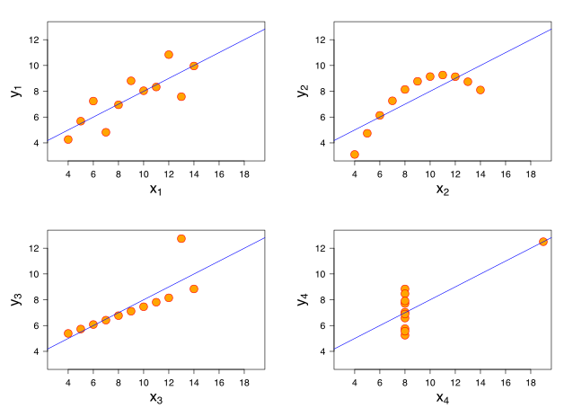

```r
anscombe %>%
  pivot_longer(everything(),
    names_to = c(".value", "set"),
    names_pattern = "(.)(.)"
  ) %>%
  arrange(set)
```

| set | x | y |
| --- | --- | --- |
| 1 | 10 | 8.04 |
| 1 | 8 | 6.95 |
| 1 | 13 | 7.58 |
| 1 | 9 | 8.81 |
| 1 | 11 | 8.33 |
| 1 | 14 | 9.96 |
| 1 | 6 | 7.24 |
| 1 | 4 | 4.26 |
| 1 | 12 | 10.84 |
| 1 | 7 | 4.82 |

[output cut: 34 more lines]

另外一个例子：面板数据雏形

```r
pnl <- tibble(
  x = 1:4,
  a = c(1, 1,0, 0),
  b = c(0, 1, 1, 1),
  y1 = rnorm(4),
  y2 = rnorm(4),
  z1 = rep(3, 4),
  z2 = rep(-2, 4),
)
pnl
```

| x | a | b | y1 | y2 | z1 | z2 |
| --- | --- | --- | --- | --- | --- | --- |
| 1 | 1 | 0 | 0.5692830 | -1.066522957 | 3 | -2 |
| 2 | 1 | 1 | -1.6025722 | -0.008317245 | 3 | -2 |
| 3 | 0 | 1 | -2.3943097 | -0.227967456 | 3 | -2 |
| 4 | 0 | 1 | -0.4024539 | 0.874468537 | 3 | -2 |

```r
pnl %>%
  pivot_longer(
    -c(x, a, b),
    names_to = c(".value", "time"),
    names_pattern = "(.)(.)"
  )
```

| x | a | b | time | y | z |
| --- | --- | --- | --- | --- | --- |
| 1 | 1 | 0 | 1 | 0.569283034 | 3 |
| 1 | 1 | 0 | 2 | -1.066522957 | -2 |
| 2 | 1 | 1 | 1 | -1.602572180 | 3 |
| 2 | 1 | 1 | 2 | -0.008317245 | -2 |
| 3 | 0 | 1 | 1 | -2.394309676 | 3 |
| 3 | 0 | 1 | 2 | -0.227967456 | -2 |
| 4 | 0 | 1 | 1 | -0.402453945 | 3 |
| 4 | 0 | 1 | 2 | 0.874468537 | -2 |

# 典型场景5： 重复的列名

```r
df <- tibble(x = 1:3, y = 4:6, y = 5:7, y = 7:9, .name_repair = "minimal")
df
```

| x | y | y | y |
| --- | --- | --- | --- |
| 1 | 4 | 5 | 7 |
| 2 | 5 | 6 | 8 |
| 3 | 6 | 7 | 9 |

```r
df %>% pivot_longer(-x, names_to = "name", values_to = "value")
```

```
Duplicate column names detected, adding .copy variable
```

| x | name | .copy | value |
| --- | --- | --- | --- |
| 1 | y | 1 | 4 |
| 1 | y | 2 | 5 |
| 1 | y | 3 | 7 |
| 2 | y | 1 | 5 |
| 2 | y | 2 | 6 |
| 2 | y | 3 | 8 |
| 3 | y | 1 | 6 |
| 3 | y | 2 | 7 |
| 3 | y | 3 | 9 |

# Wider: 拉宽数据

相对来说，longer数据比wider数据更干净(tidy), 符合tidyr和类似plm包的数据格式要求。但有些时候，宽数据更适合做数据展示。其他软件也可能要求数据输入格式为wider。

```r
fish_encounters
```

| fish | station | seen |
| --- | --- | --- |
| 4842 | Release | 1 |
| 4842 | I80_1 | 1 |
| 4842 | Lisbon | 1 |
| 4842 | Rstr | 1 |
| 4842 | Base_TD | 1 |
| 4842 | BCE | 1 |
| 4842 | BCW | 1 |
| 4842 | BCE2 | 1 |
| 4842 | BCW2 | 1 |
| 4842 | MAE | 1 |

[output cut: 104 more lines]

很多分析方法要求将station放在列上（变宽）：

```r
fish_encounters %>% pivot_wider(names_from = station, values_from = seen)
```

| fish | Release | I80_1 | Lisbon | Rstr | Base_TD | BCE | BCW | BCE2 | BCW2 | MAE | MAW |
| --- | --- | --- | --- | --- | --- | --- | --- | --- | --- | --- | --- |
| 4842 | 1 | 1 | 1 | 1 | 1 | 1 | 1 | 1 | 1 | 1 | 1 |
| 4843 | 1 | 1 | 1 | 1 | 1 | 1 | 1 | 1 | 1 | 1 | 1 |
| 4844 | 1 | 1 | 1 | 1 | 1 | 1 | 1 | 1 | 1 | 1 | 1 |
| 4845 | 1 | 1 | 1 | 1 | 1 | NA | NA | NA | NA | NA | NA |
| 4847 | 1 | 1 | 1 | NA | NA | NA | NA | NA | NA | NA | NA |
| 4848 | 1 | 1 | 1 | 1 | NA | NA | NA | NA | NA | NA | NA |
| 4849 | 1 | 1 | NA | NA | NA | NA | NA | NA | NA | NA | NA |
| 4850 | 1 | 1 | NA | 1 | 1 | 1 | 1 | NA | NA | NA | NA |
| 4851 | 1 | 1 | NA | NA | NA | NA | NA | NA | NA | NA | NA |
| 4854 | 1 | 1 | NA | NA | NA | NA | NA | NA | NA | NA | NA |

[output cut: 9 more lines]

很多缺失值NA，为什么？其实不是确实，而是有真实含义。因此：

```r
fish_encounters %>% pivot_wider(
  names_from = station,
  values_from = seen,
  values_fill = list(seen = 0)
)
```

| fish | Release | I80_1 | Lisbon | Rstr | Base_TD | BCE | BCW | BCE2 | BCW2 | MAE | MAW |
| --- | --- | --- | --- | --- | --- | --- | --- | --- | --- | --- | --- |
| 4842 | 1 | 1 | 1 | 1 | 1 | 1 | 1 | 1 | 1 | 1 | 1 |
| 4843 | 1 | 1 | 1 | 1 | 1 | 1 | 1 | 1 | 1 | 1 | 1 |
| 4844 | 1 | 1 | 1 | 1 | 1 | 1 | 1 | 1 | 1 | 1 | 1 |
| 4845 | 1 | 1 | 1 | 1 | 1 | 0 | 0 | 0 | 0 | 0 | 0 |
| 4847 | 1 | 1 | 1 | 0 | 0 | 0 | 0 | 0 | 0 | 0 | 0 |
| 4848 | 1 | 1 | 1 | 1 | 0 | 0 | 0 | 0 | 0 | 0 | 0 |
| 4849 | 1 | 1 | 0 | 0 | 0 | 0 | 0 | 0 | 0 | 0 | 0 |
| 4850 | 1 | 1 | 0 | 1 | 1 | 1 | 1 | 0 | 0 | 0 | 0 |
| 4851 | 1 | 1 | 0 | 0 | 0 | 0 | 0 | 0 | 0 | 0 | 0 |
| 4854 | 1 | 1 | 0 | 0 | 0 | 0 | 0 | 0 | 0 | 0 | 0 |

[output cut: 9 more lines]

## 汇总

```r
warpbreaks <- warpbreaks %>% as_tibble() %>% select(wool, tension, breaks)
warpbreaks
```

| wool | tension | breaks |
| --- | --- | --- |
| A | L | 26 |
| A | L | 30 |
| A | L | 54 |
| A | L | 25 |
| A | L | 70 |
| A | L | 52 |
| A | L | 51 |
| A | L | 26 |
| A | L | 67 |
| A | M | 18 |

[output cut: 44 more lines]

```r
warpbreaks %>% count(wool, tension)
```

| wool | tension | n |
| --- | --- | --- |
| A | L | 9 |
| A | M | 9 |
| A | H | 9 |
| B | L | 9 |
| B | M | 9 |
| B | H | 9 |

以下为什么报警？

```r
warpbreaks %>% pivot_wider(names_from = wool, values_from = breaks)
```

```
Values in `breaks` are not uniquely identified; output will contain list-cols.
* Use `values_fn = list(breaks = list)` to suppress this warning.
* Use `values_fn = list(breaks = length)` to identify where the duplicates arise
* Use `values_fn = list(breaks = summary_fun)` to summarise duplicates
```

| tension | A | B |
| --- | --- | --- |
| L |  |  |
| M |  |  |
| H |  |  |

```r
warpbreaks %>%
  pivot_wider(
    names_from = wool,
    values_from = breaks,
    values_fn = list(breaks = mean)
  )
```

| tension | A | B |
| --- | --- | --- |
| L | 44.55556 | 28.22222 |
| M | 24.00000 | 28.77778 |
| H | 24.55556 | 18.77778 |

# 典型场景：从多个变量生成一列

```r
production <- expand_grid(
    product = c("A", "B"),
    country = c("AI", "EI"),
    year = 2000:2014
  ) %>%
  dplyr::filter((product == "A" & country == "AI") | product == "B") %>%
  mutate(production = rnorm(nrow(.)))
production
```

| product | country | year | production |
| --- | --- | --- | --- |
| A | AI | 2000 | 0.63333771 |
| A | AI | 2001 | 1.72723102 |
| A | AI | 2002 | 0.52531627 |
| A | AI | 2003 | 0.52876909 |
| A | AI | 2004 | 0.50255538 |
| A | AI | 2005 | 0.45062495 |
| A | AI | 2006 | 0.03169142 |
| A | AI | 2007 | -0.22455280 |
| A | AI | 2008 | -0.18261733 |
| A | AI | 2009 | 0.04412224 |

[output cut: 35 more lines]

```r
production %>% pivot_wider(
  names_from = c(product, country),
  values_from = production
)
```

| year | A_AI | B_AI | B_EI |
| --- | --- | --- | --- |
| 2000 | 0.63333771 | 0.4152837 | -1.9737397 |
| 2001 | 1.72723102 | -2.0156384 | 0.7147667 |
| 2002 | 0.52531627 | -0.1789207 | 0.1055598 |
| 2003 | 0.52876909 | -1.6689142 | 1.1326477 |
| 2004 | 0.50255538 | -0.8937964 | 0.1420592 |
| 2005 | 0.45062495 | -1.2312752 | -1.0121103 |
| 2006 | 0.03169142 | 2.3992653 | 0.9395299 |
| 2007 | -0.22455280 | 1.0762732 | 0.5952980 |
| 2008 | -0.18261733 | 0.2775399 | -0.5867795 |
| 2009 | 0.04412224 | -0.5890049 | 0.1704079 |

[output cut: 5 more lines]

# tidy census 调查数据

us_rent_income 包括2017年美国收入和租金支出数据。

```r
us_rent_income
```

| GEOID | NAME | variable | estimate | moe |
| --- | --- | --- | --- | --- |
| 01 | Alabama | income | 24476 | 136 |
| 01 | Alabama | rent | 747 | 3 |
| 02 | Alaska | income | 32940 | 508 |
| 02 | Alaska | rent | 1200 | 13 |
| 04 | Arizona | income | 27517 | 148 |
| 04 | Arizona | rent | 972 | 4 |
| 05 | Arkansas | income | 23789 | 165 |
| 05 | Arkansas | rent | 709 | 5 |
| 06 | California | income | 29454 | 109 |
| 06 | California | rent | 1358 | 3 |

[output cut: 94 more lines]

这个数据有什么不干净的地方？

```r
us_rent_income %>%
  pivot_wider(names_from = variable, values_from = c(estimate, moe))
```

| GEOID | NAME | estimate_income | estimate_rent | moe_income | moe_rent |
| --- | --- | --- | --- | --- | --- |
| 01 | Alabama | 24476 | 747 | 136 | 3 |
| 02 | Alaska | 32940 | 1200 | 508 | 13 |
| 04 | Arizona | 27517 | 972 | 148 | 4 |
| 05 | Arkansas | 23789 | 709 | 165 | 5 |
| 06 | California | 29454 | 1358 | 109 | 3 |
| 08 | Colorado | 32401 | 1125 | 109 | 5 |
| 09 | Connecticut | 35326 | 1123 | 195 | 5 |
| 10 | Delaware | 31560 | 1076 | 247 | 10 |
| 11 | District of Columbia | 43198 | 1424 | 681 | 17 |
| 12 | Florida | 25952 | 1077 | 70 | 3 |

[output cut: 42 more lines]

# contact 列表数据

```r
contacts <- tribble(
  ~field, ~value,
  "name", "Jiena McLellan",
  "company", "Toyota",
  "name", "John Smith",
  "company", "google",
  "email", "john@google.com",
  "name", "Huxley Ratcliffe"
)
contacts
```

| field | value |
| --- | --- |
| name | Jiena McLellan |
| company | Toyota |
| name | John Smith |
| company | google |
| email | john@google.com |
| name | Huxley Ratcliffe |

没有id标识

```r
contacts <- contacts %>%
  mutate(
    person_id = cumsum(field == "name")
  )
contacts
```

| field | value | person_id |
| --- | --- | --- |
| name | Jiena McLellan | 1 |
| company | Toyota | 1 |
| name | John Smith | 2 |
| company | google | 2 |
| email | john@google.com | 2 |
| name | Huxley Ratcliffe | 3 |

```r
contacts %>%
  pivot_wider(names_from = field, values_from = value)
```

| person_id | name | company | email |
| --- | --- | --- | --- |
| 1 | Jiena McLellan | Toyota | NA |
| 2 | John Smith | google | john@google.com |
| 3 | Huxley Ratcliffe | NA | NA |

# longer, then wider: 长宽操作组合

```r
world_bank_pop
```

| country | indicator | 2000 | 2001 | 2002 | 2003 | 2004 | 2005 | 2006 | 2007 | 2008 | 2009 | 2010 | 2011 | 2012 | 2013 | 2014 | 2015 | 2016 | 2017 |
| --- | --- | --- | --- | --- | --- | --- | --- | --- | --- | --- | --- | --- | --- | --- | --- | --- | --- | --- | --- |
| ABW | SP.URB.TOTL | 4.244400e+04 | 4.304800e+04 | 4.367000e+04 | 4.424600e+04 | 4.466900e+04 | 4.488900e+04 | 4.488100e+04 | 4.468600e+04 | 4.437500e+04 | 4.405200e+04 | 4.377800e+04 | 4.382200e+04 | 4.406400e+04 | 4.436000e+04 | 4.467400e+04 | 4.497900e+04 | 4.527500e+04 | 4.557200e+04 |
| ABW | SP.URB.GROW | 1.182632e+00 | 1.413021e+00 | 1.434560e+00 | 1.310360e+00 | 9.514777e-01 | 4.913027e-01 | -1.782333e-02 | -4.354289e-01 | -6.984006e-01 | -7.305493e-01 | -6.239346e-01 | 1.004566e-01 | 5.507148e-01 | 6.695040e-01 | 7.053514e-01 | 6.804037e-01 | 6.559290e-01 | 6.538489e-01 |
| ABW | SP.POP.TOTL | 9.085300e+04 | 9.289800e+04 | 9.499200e+04 | 9.701700e+04 | 9.873700e+04 | 1.000310e+05 | 1.008320e+05 | 1.012200e+05 | 1.013530e+05 | 1.014530e+05 | 1.016690e+05 | 1.020530e+05 | 1.025770e+05 | 1.031870e+05 | 1.037950e+05 | 1.043410e+05 | 1.048220e+05 | 1.052640e+05 |
| ABW | SP.POP.GROW | 2.055027e+00 | 2.225930e+00 | 2.229056e+00 | 2.109354e+00 | 1.757353e+00 | 1.302039e+00 | 7.975628e-01 | 3.840600e-01 | 1.313107e-01 | 9.861642e-02 | 2.126801e-01 | 3.769848e-01 | 5.121450e-01 | 5.929140e-01 | 5.874924e-01 | 5.246582e-01 | 4.599292e-01 | 4.207807e-01 |
| AFG | SP.URB.TOTL | 4.436299e+06 | 4.648055e+06 | 4.892951e+06 | 5.155686e+06 | 5.426770e+06 | 5.691823e+06 | 5.931413e+06 | 6.151939e+06 | 6.364968e+06 | 6.588859e+06 | 6.837008e+06 | 7.114615e+06 | 7.416385e+06 | 7.733964e+06 | 8.054214e+06 | 8.367663e+06 | 8.670939e+06 | 8.971345e+06 |
| AFG | SP.URB.GROW | 3.912228e+00 | 4.662838e+00 | 5.134675e+00 | 5.230459e+00 | 5.124393e+00 | 4.768647e+00 | 4.123188e+00 | 3.650485e+00 | 3.404189e+00 | 3.457099e+00 | 3.697002e+00 | 3.980091e+00 | 4.154062e+00 | 4.192980e+00 | 4.057389e+00 | 3.817920e+00 | 3.560246e+00 | 3.405852e+00 |
| AFG | SP.POP.TOTL | 2.009376e+07 | 2.096646e+07 | 2.197992e+07 | 2.306485e+07 | 2.411898e+07 | 2.507080e+07 | 2.589345e+07 | 2.661679e+07 | 2.729403e+07 | 2.800433e+07 | 2.880317e+07 | 2.970860e+07 | 3.069696e+07 | 3.173169e+07 | 3.275802e+07 | 3.373649e+07 | 3.465603e+07 | 3.553008e+07 |
| AFG | SP.POP.GROW | 3.494659e+00 | 4.251504e+00 | 4.720528e+00 | 4.818041e+00 | 4.468918e+00 | 3.870470e+00 | 3.228630e+00 | 2.755225e+00 | 2.512574e+00 | 2.569114e+00 | 2.812617e+00 | 3.095119e+00 | 3.272703e+00 | 3.315224e+00 | 3.183201e+00 | 2.943234e+00 | 2.689163e+00 | 2.490790e+00 |
| AGO | SP.URB.TOTL | 8.234766e+06 | 8.708000e+06 | 9.218787e+06 | 9.765197e+06 | 1.034351e+07 | 1.094942e+07 | 1.150175e+07 | 1.207871e+07 | 1.268183e+07 | 1.331190e+07 | 1.397077e+07 | 1.465901e+07 | 1.537591e+07 | 1.611949e+07 | 1.688748e+07 | 1.767562e+07 | 1.848355e+07 | 1.931177e+07 |
| AGO | SP.URB.GROW | 5.437494e+00 | 5.587720e+00 | 5.700132e+00 | 5.758127e+00 | 5.753414e+00 | 5.692797e+00 | 4.921217e+00 | 4.894529e+00 | 4.872555e+00 | 4.848851e+00 | 4.830877e+00 | 4.808822e+00 | 4.774657e+00 | 4.722723e+00 | 4.654324e+00 | 4.561361e+00 | 4.469503e+00 | 4.383387e+00 |

[output cut: 990 more lines]

这个数据很不干净，我们从最明显的问题开始处理： - 第一个问题：年份跨列，这应该是个longer操作

```r
pop2 <- world_bank_pop %>%
  pivot_longer(`2000`:`2017`, names_to = "year", values_to = "value")
pop2
```

| country | indicator | year | value |
| --- | --- | --- | --- |
| ABW | SP.URB.TOTL | 2000 | 4.244400e+04 |
| ABW | SP.URB.TOTL | 2001 | 4.304800e+04 |
| ABW | SP.URB.TOTL | 2002 | 4.367000e+04 |
| ABW | SP.URB.TOTL | 2003 | 4.424600e+04 |
| ABW | SP.URB.TOTL | 2004 | 4.466900e+04 |
| ABW | SP.URB.TOTL | 2005 | 4.488900e+04 |
| ABW | SP.URB.TOTL | 2006 | 4.488100e+04 |
| ABW | SP.URB.TOTL | 2007 | 4.468600e+04 |
| ABW | SP.URB.TOTL | 2008 | 4.437500e+04 |
| ABW | SP.URB.TOTL | 2009 | 4.405200e+04 |

[output cut: 990 more lines]

- 第二个问题：indicator的信息冗余

```r
pop2 %>% count(indicator)
```

| indicator | n |
| --- | --- |
| SP.POP.GROW | 4752 |
| SP.POP.TOTL | 4752 |
| SP.URB.GROW | 4752 |
| SP.URB.TOTL | 4752 |

“SP.POP.GROW is population growth, SP.POP.TOTL is total population, and SP.URB.* are the same but only for urban areas.”

应该有两个变量：area，表示total和urban； 还有两个实际变量：population和growth

首先需要用到separate

```r
pop3 <- pop2 %>%
  separate(indicator, c(NA, "area", "variable"))
pop3
```

| country | area | variable | year | value |
| --- | --- | --- | --- | --- |
| ABW | URB | TOTL | 2000 | 4.244400e+04 |
| ABW | URB | TOTL | 2001 | 4.304800e+04 |
| ABW | URB | TOTL | 2002 | 4.367000e+04 |
| ABW | URB | TOTL | 2003 | 4.424600e+04 |
| ABW | URB | TOTL | 2004 | 4.466900e+04 |
| ABW | URB | TOTL | 2005 | 4.488900e+04 |
| ABW | URB | TOTL | 2006 | 4.488100e+04 |
| ABW | URB | TOTL | 2007 | 4.468600e+04 |
| ABW | URB | TOTL | 2008 | 4.437500e+04 |
| ABW | URB | TOTL | 2009 | 4.405200e+04 |

[output cut: 990 more lines]

- 第三个问题：variable包括了两个实际变量，需要wider操作。

```r
pop3 %>%
  pivot_wider(names_from = variable, values_from = value)
```

| country | area | year | TOTL | GROW |
| --- | --- | --- | --- | --- |
| ABW | URB | 2000 | 42444 | 1.182632371 |
| ABW | URB | 2001 | 43048 | 1.413021218 |
| ABW | URB | 2002 | 43670 | 1.434559531 |
| ABW | URB | 2003 | 44246 | 1.310360439 |
| ABW | URB | 2004 | 44669 | 0.951477684 |
| ABW | URB | 2005 | 44889 | 0.491302715 |
| ABW | URB | 2006 | 44881 | -0.017823326 |
| ABW | URB | 2007 | 44686 | -0.435428915 |
| ABW | URB | 2008 | 44375 | -0.698400566 |
| ABW | URB | 2009 | 44052 | -0.730549349 |

[output cut: 990 more lines]

# 典型场景：多选题数据

```r
multi <- tribble(
  ~id, ~choice1, ~choice2, ~choice3,
  1, "A", "B", "C",
  2, "C", "B",  NA,
  3, "D",  NA,  NA,
  4, "B", "D",  NA
)
multi
```

| id | choice1 | choice2 | choice3 |
| --- | --- | --- | --- |
| 1 | A | B | C |
| 2 | C | B | NA |
| 3 | D | NA | NA |
| 4 | B | D | NA |

先longer

```r
multi2 <- multi %>%
  pivot_longer(-id, values_drop_na = TRUE) %>%
  mutate(checked = TRUE)
multi2
```

| id | name | value | checked |
| --- | --- | --- | --- |
| 1 | choice1 | A | TRUE |
| 1 | choice2 | B | TRUE |
| 1 | choice3 | C | TRUE |
| 2 | choice1 | C | TRUE |
| 2 | choice2 | B | TRUE |
| 3 | choice1 | D | TRUE |
| 4 | choice1 | B | TRUE |
| 4 | choice2 | D | TRUE |

再wider

```r
multi2 %>%
  pivot_wider(
    id_cols = id,
    names_from = value,
    values_from = checked,
    values_fill = list(checked = FALSE)
  )
```

| id | A | B | C | D |
| --- | --- | --- | --- | --- |
| 1 | TRUE | TRUE | TRUE | FALSE |
| 2 | FALSE | TRUE | TRUE | FALSE |
| 3 | FALSE | FALSE | FALSE | TRUE |
| 4 | FALSE | TRUE | FALSE | TRUE |